# Número/Ratio de Camas por propiedad y paises

Alicia Perdices Guerra

3 de mayo, 2021

#### **1.PROCESAMIENTO DE LOS DATOS.**

- En primer lugar leemos el fichero:

```r
camas<-read.csv("C:/temp/Camas_Propiedad.csv",sep= ",")
```

- Realicemos una breve inspección de los datos

```r
str(camas)
```

```
## 'data.frame':    2790 obs. of  6 variables:
##  $ TIME              : int  2010 2010 2010 2010 2010 2010 2010 2010 2010 2010 ...
##  $ GEO               : Factor w/ 31 levels "Austria","Belgium",..: 2 2 2 2 2 2 2 2 2 3 ...
##  $ OWNER             : Factor w/ 3 levels "For-profit private ownership",..: 3 3 3 2 2 2 1 1 1 3 ...
##  $ UNIT              : Factor w/ 3 levels "Inhabitants per ...",..: 2 1 3 2 1 3 2 1 3 2 ...
##  $ Value             : Factor w/ 1704 levels ":","0.00","0.98",..: 454 1426 385 1225 643 1174 1 1 1 1149 ...
##  $ Flag.and.Footnotes: Factor w/ 4 levels "","b","e","p": 1 1 1 1 1 1 1 1 1 1 ...
```

```r
colnames(camas) #Nombre de las variables
```

```
## [1] "TIME"               "GEO"                "OWNER"
## [4] "UNIT"               "Value"              "Flag.and.Footnotes"
```

```r
nrow(camas) #Número de registros
```

```
## [1] 2790
```

```r
ncol(camas) #Número de variables
```

```
## [1] 6
```

*Observamos las siguientes variables:

- **TIME**: variable cuantitativa. Indica el año en el que se ha realizado la medida, en este caso el valor de la variable “Value”. Se ha cargado bien como número entero.
- **GEO**: variable cualitativa. Indica el país o región en el que se ha realizado la medida.Se ha cargado bien como factor.
- **UNIT**: variable cualitativa. Indica la medida de la variable valor.Se ha cargado bien como factor.
- **OWNER**: variable cualitativa. Indica la propiedad de las camas hospitalarias.
- **Value**: Variable cuantitativa. Indica el número y ratio de camas por propiedad y por países.
- **Fal.and.footnotes**. Notas sobre etiquetas. Eliminamos esta columna.

*Años de las mediciones:

```r
unique(camas$TIME)
```

```
##  [1] 2010 2011 2012 2013 2014 2015 2016 2017 2018 2019
```

*Paises:

```r
unique(camas$GEO)
```

```
##  [1] Belgium
##  [2] Bulgaria
##  [3] Czechia
##  [4] Denmark
##  [5] Germany (until 1990 former territory of the FRG)
##  [6] Estonia
##  [7] Greece
##  [8] Spain
##  [9] France
## [10] Croatia
## [11] Italy
## [12] Cyprus
## [13] Latvia
## [14] Lithuania
## [15] Hungary
```

[output cut: 17 more lines]

*Unidad de las mediciones:

```r
unique(camas$UNIT)
```

```
## [1] Number                           Inhabitants per ...
## [3] Per hundred thousand inhabitants
## Levels: Inhabitants per ... Number Per hundred thousand inhabitants
```

- Tipo de propiedad en relación a las camas.

```r
unique(camas$OWNER)
```

```
## [1] Public ownership                 Not-for-profit private ownership
## [3] For-profit private ownership
## 3 Levels: For-profit private ownership ... Public ownership
```

- Eliminamos la columna Fal.and.footnotes.

```r
camas<-camas[,-6]
```

- Tendríamos que convertir la columna Value a numérico porque se ha cargado como factor y es erróneo. El resto de variables tienen el tipo correcto.

```r
camas$Value<-as.character(camas$Value)
camas$Value<-(gsub(',','.',camas$Value) )
camas$Value<-(gsub(' ','',camas$Value) )
camas$Value<-as.numeric(camas$Value)
```

- Comprobamos que valores tenemos en la columna **Value**:

```r
table(camas$Value, useNA = "ifany")
```

```
##
##         0      0.98      1.13       1.3      1.73      1.81      1.88      2.03
##       243         1         1         1         1         1         1         1
##      2.38      2.39       2.4      2.41      2.42      2.54      2.66      2.69
##         1         3         2         1         1         1         1         1
##      2.97         3      3.29       3.3      3.33      3.34      3.35      3.36
##         1         2         1         1         1         1         1         1
##      3.39      3.42      3.63         4      4.47      4.87      4.89      4.95
##         1         1         1         8         1         1         3         2
##      4.96      4.97      4.98      5.21      5.31      5.44      5.45      5.53
##         1         1         1         1         1         1         1         1
##      5.58      5.61      5.65      5.85         6      6.16      6.32      6.33
##         1         1         1         1         1         1         1         1
##      6.45      6.49      6.51      6.55       6.6      7.23      7.36      7.71
##         1         1         1         1         1         1         1         1
##      8.12      8.14      8.15      8.28      8.31      8.34      8.43      8.44
##         1         1         1         1         1         1         1         1
##      8.81      9.59      9.93     10.02      10.1     10.15     10.43     10.46
##         1         1         1         1         1         1         1         1
##     10.56     10.61     10.67     10.74     10.82     10.84     10.91     11.02
##         1         1         1         1         1         1         1         1
##     11.03      11.1     11.15     11.42     11.52     11.54     11.78     11.83
##         1         1         1         1         1         1         1         1
##     11.86     12.22     12.26      12.3     12.32     12.39     12.46     12.49
##         1         1         1         1         1         1         1         1
##     12.61     12.62      12.7     12.77     12.91     12.92      13.1     13.18
##         1         1         1         1         1         1         1         2
##     13.38      13.8     13.81     13.88     14.78     15.43     15.87     16.99
##         1         1         1         1         1         1         1         1
##     17.48     18.87     18.89     19.23     20.32     20.63     20.85        21
##         1         1         1         1         1         1         1         1
##     22.29     22.35     23.57     23.68     23.76     23.79     24.02     24.16
##         1         1         1         1         2         1         1         1
##     24.27     24.41     24.62     25.56     25.58     26.49     26.59     26.79
##         1         1         1         1         1         1         1         1
##     26.82     27.14     28.12     28.24     28.41     28.67     28.68     28.99
##         1         1         1         1         1         1         1         1
##      29.8     30.59     32.78     33.14     33.73     34.93        35     35.76
##         1         1         1         1         1         1         2         1
##     36.07     36.28     36.35     36.41     36.52     36.53     36.93     36.99
```

[output cut: 372 more lines]

```
##         1         1         1         1         1         1         1         1
##    160594    161058    162126    162769 163873.04 165844.39    167074    167589
##         1         1         1         1         1         1         1         1
##    168661    168934    169995    172310    176324    176791    177189    178841
##         1         1         1         1         1         1         1         1
##    181972    183831    184549    190175    191111    193286    193358    195052
##         1         1         1         1         1         1         1         1
##    197267    198412    198736    198877    198911    199842    200012    200206
##         1         1         1         1         1         1         1         1
##    200280    200672    200889    201218    201425    202523    243417    246395
##         1         1         1         1         1         1         1         1
##    250104    253364    256229    256957    258158    258444    260642    269158
##         1         1         1         1         1         1         1         1
##    269448    270813    271079    271236    271557    273382    273789      <NA>
##         1         1         1         1         1         1         1       786
```

- Observamos que tenemos **786 valores perdidos**.Guardamos en la variable **idx** los índices de los registros con valores **NA** de la variable **Value**.

```r
idx<-which(is.na(camas$Value))
length(idx)
```

```
## [1] 786
```

- Grafiquemos la información que contiene la variable **Value**

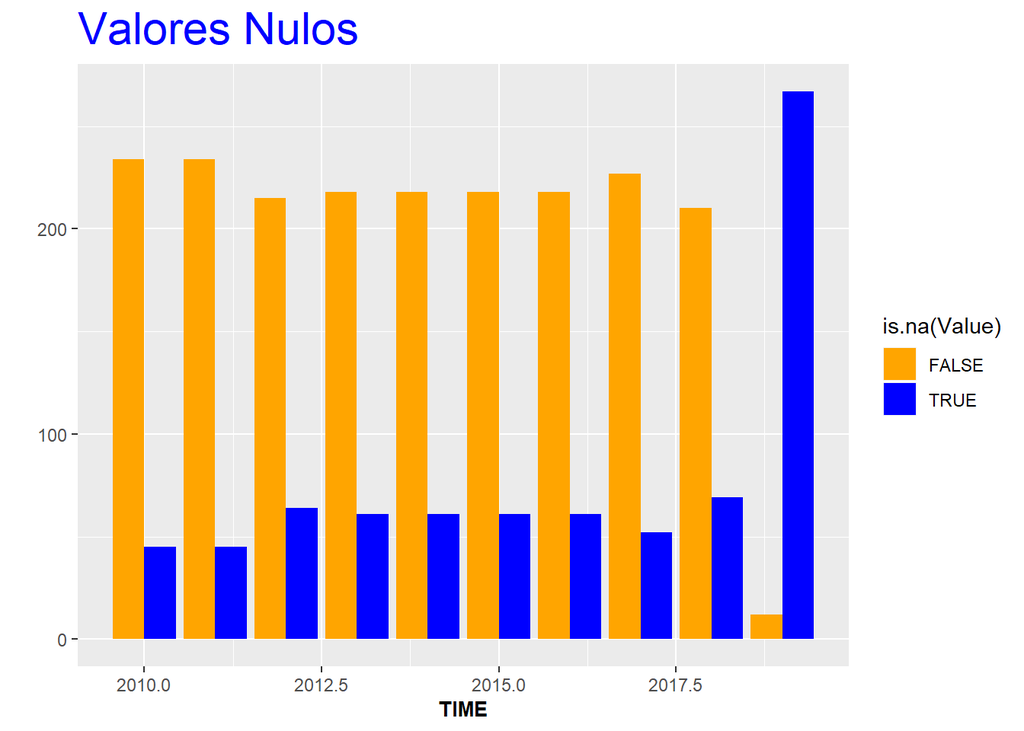

```r
library(ggplot2)
library(scales)
g = ggplot(camas, aes(TIME, fill=is.na(Value)) ) +
labs(title = "Valores Nulos")+ylab("") +
theme(plot.title = element_text(size = rel(2), colour = "blue"))

g+geom_bar(position="dodge") + scale_fill_manual(values = alpha(c("orange", "blue"), 1)) +
theme(axis.title.x = element_text(face="bold", size=10))
```

- En caso de detectar algún valor anómalo (en nuestro caso los NAS) en las variables tendríamos que realizar una imputación de esos valores o bien sustituyéndolos por la media o usando el algoritmo KNN ( k-Nearest Neighbour) con los 3 vecinos más cercanos usando la distancia que consideremos, en este caso usaremos Gower(Mediana), por ser una medida más robusa frente a extremos.

```r
library(VIM)
output<-kNN(camas, variable=c("Value"),k=3)
camas<-output
```

- Comprobamos que no tenemos valores nulos después de la imputación

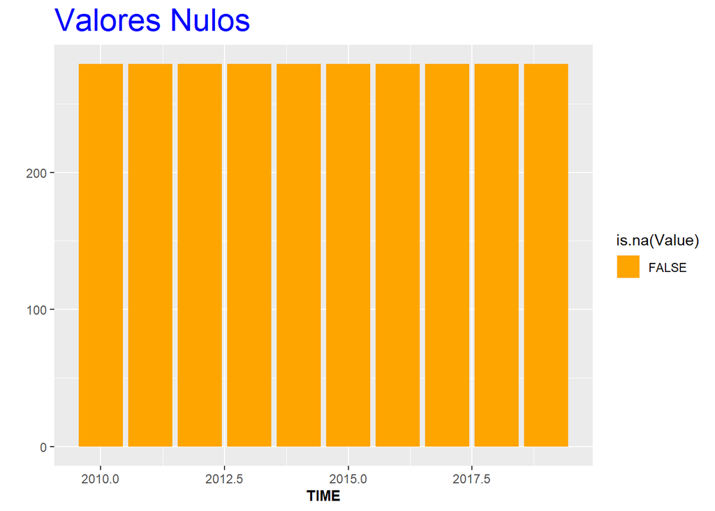

```r
g = ggplot(camas, aes(TIME, fill=is.na(Value)) ) +
labs(title = "Valores Nulos")+ylab("") +
theme(plot.title = element_text(size = rel(2), colour = "blue"))

g+geom_bar(position="dodge") + scale_fill_manual(values = alpha(c("orange", "blue"), 1)) +
theme(axis.title.x = element_text(face="bold", size=10))
```

- Con el siguiente gráfico, observaremos que la variable **Value** tiene outliers o valores extremos

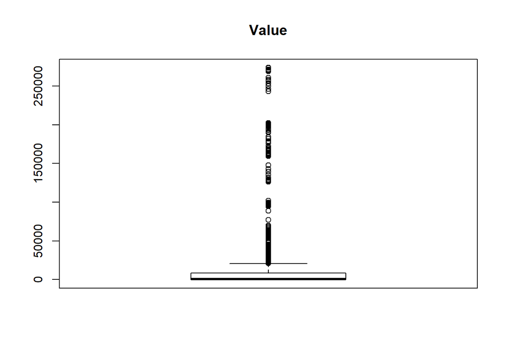

```r
boxplot(camas$Value, main="Value")
```

- Por otro lado, revisamos para el resto de columnas si tenemos valores NA.(desconocidos o perdidos)

```r
table(camas$TIME, useNA = "ifany")
```

```
##
## 2010 2011 2012 2013 2014 2015 2016 2017 2018 2019
##  279  279  279  279  279  279  279  279  279  279
```

```r
table(camas$GEO, useNA = "ifany")
```

```
##
##                                          Austria
##                                               90
##                                          Belgium
##                                               90
##                                         Bulgaria
##                                               90
##                                          Croatia
##                                               90
##                                           Cyprus
##                                               90
##                                          Czechia
##                                               90
##                                          Denmark
##                                               90
##                                          Estonia
##                                               90
##                                          Finland
##                                               90
##                                           France
##                                               90
## Germany (until 1990 former territory of the FRG)
##                                               90
##                                           Greece
##                                               90
##                                          Hungary
##                                               90
##                                          Iceland
##                                               90
##                                            Italy
##                                               90
##                                           Latvia
##                                               90
##                                    Liechtenstein
##                                               90
##                                        Lithuania
##                                               90
##                                            Malta
##                                               90
##                                       Montenegro
```

[output cut: 8 more lines]

```
##                                               90
##                                         Portugal
##                                               90
##                                          Romania
##                                               90
##                                           Serbia
##                                               90
##                                         Slovenia
##                                               90
##                                            Spain
##                                               90
##                                           Turkey
##                                               90
##                                   United Kingdom
##                                               90
```

```r
table(camas$UNIT, useNA = "ifany")
```

```
##
##              Inhabitants per ...                           Number
##                              930                              930
## Per hundred thousand inhabitants
##                              930
```

```r
table(camas$OWNER, useNA = "ifany")
```

```
##
##     For-profit private ownership Not-for-profit private ownership
##                              930                              930
##                 Public ownership
##                              930
```

Observamos que no existen ahora valores perdidos después de la imputación.La suma de las cantidades de cada variable, suman el total.

- Finalmente, creamos un fichero con toda la información corregida.

```r
write.csv(camas, file="Camas_Propiedad_clean.csv", row.names = FALSE)
```